# The Third Classification of the Arabian Shield

Dr. Ahmad Redaa

2026-02-25

## Learning Outcomes

By the end of this lecture, you will be able to:

1. Describe the **main components** of the Third Classification.
2. Explain the **three layered sequences** and their age brackets.
3. List the **regional components** of each sequence and briefly characterize them.
4. Correlate the **3rd classification** with the **1st and 2nd classifications**.

## First Classification

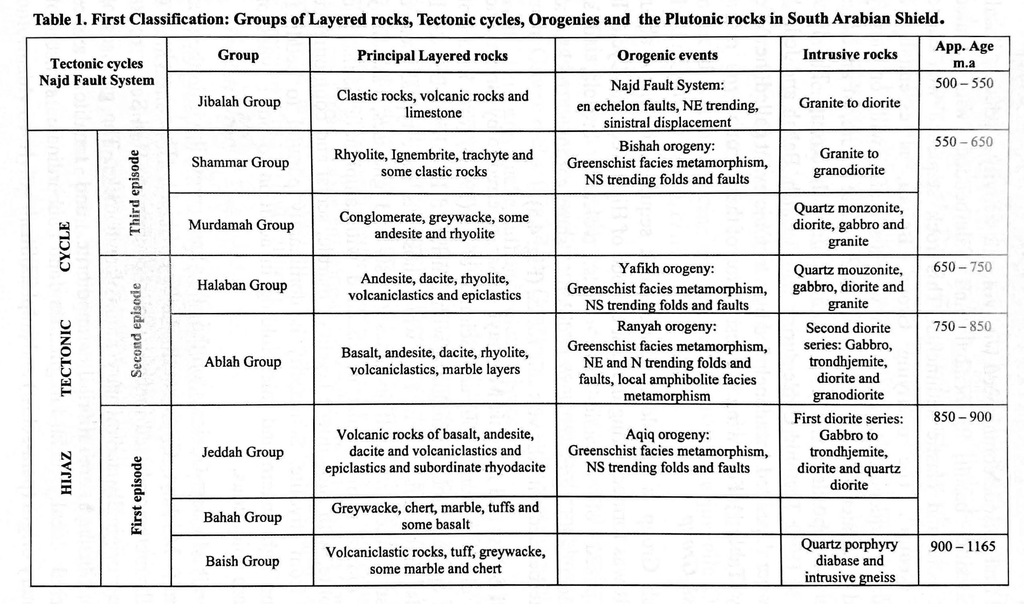

[A. M. S. Al-Shanti, “Geology of the Arabian Shield of Saudi Arabia,” Scientific Publishing Center, King Abdulaziz University, 2009, p.190.]

## Second Classification

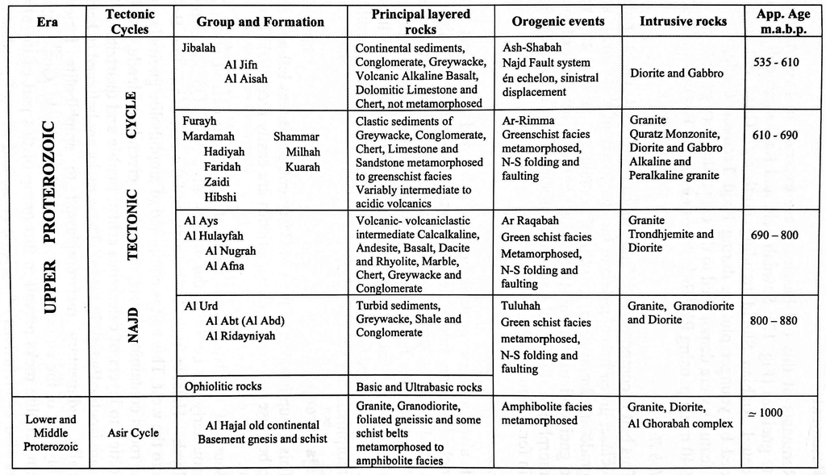

[A. M. S. Al-Shanti, “Geology of the Arabian Shield of Saudi Arabia,” Scientific Publishing Center, King Abdulaziz University, 2009, p.190.]

## Third classification

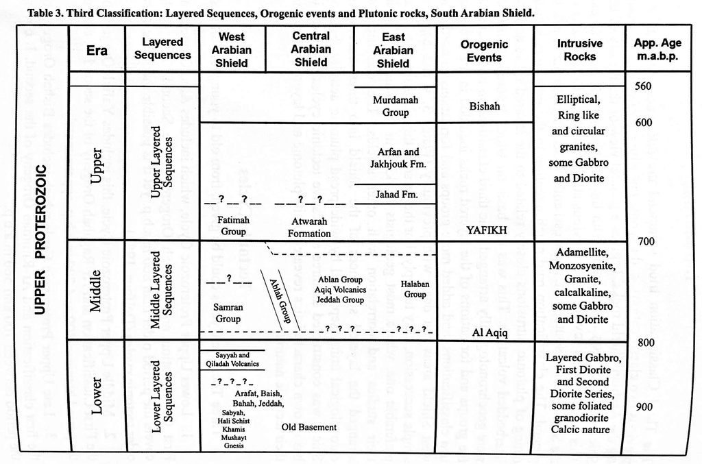

[A. M. S. Al-Shanti, “Geology of the Arabian Shield of Saudi Arabia,” Scientific Publishing Center, King Abdulaziz University, 2009, p.190.]

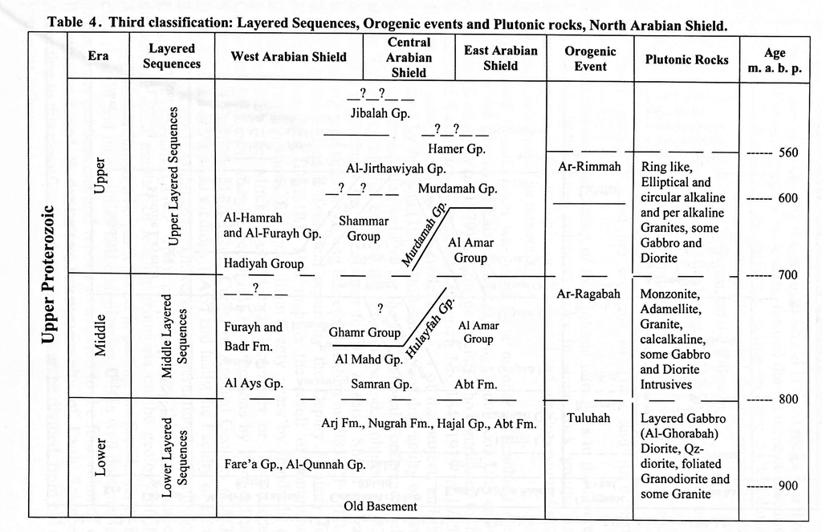

[A. M. S. Al-Shanti, “Geology of the Arabian Shield of Saudi Arabia,” Scientific Publishing Center, King Abdulaziz University, 2009, p.190.]

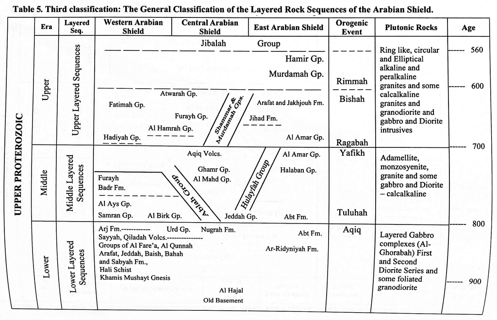

[A. M. S. Al-Shanti, “Geology of the Arabian Shield of Saudi Arabia,” Scientific Publishing Center, King Abdulaziz University, 2009, p.190.]

## Why a Third Classification?

- Developed to **amend differences** between the 1st and 2nd classifications.
- Aims to produce a **unified framework** applicable across the entire Arabian Shield.
- Emphasizes:
  - **Geochronology of plutonic intrusions**
  - Chronological ordering of layered successions
- Retains many earlier unit names but reorganizes them into a clearer framework.

## Conceptual Framework

The Arabian Shield evolved through:

### Three Upper Proterozoic Tectonic Cycles

1. **Lower Cycle** – older than 800 Ma
2. **Middle Cycle** – 800–700 Ma
3. **Late Cycle** – 700–560 Ma

Each cycle is characterized by: - Distinct layered sequences - Characteristic plutonic suites - Regional deformation events (orogenies)

## Orogeny Correlation (Unifying 1st & 2nd Classifications)

The Third Classification merges equivalent names:

- **Aqiq (1st)** = **Tuluhah (2nd)** → Aqiq–Tuluhah
- **Yafikh (1st)** = **Ar-Ragabah (2nd)** → Yafikh–Ar-Ragabah
- **Bishah (1st)** = **Ar-Rimmah (2nd)** → Bishah–Ar-Rimmah

This provides a unified tectonic terminology.

# The Three Layered Sequences

## 1. Lower Layered Sequences (>800 Ma)

### General Characteristics

- Dominated by **tholeiitic basaltic volcanism**
- Early arc and oceanic crust environments
- Interbedded with sedimentary successions
- Strong regional metamorphism

### Lower Sequence – Southern Shield Units

- **Baish Group**
  - Basic volcanic succession
  - Tholeiitic affinity
- **Bahah Group**
  - Interbedded volcaniclastic and sedimentary rocks
- **Jeddah Group (lower parts)**
  - Andesite and derivatives
- **Sabyah Formation**
  - Quartzite, conglomerate, carbonaceous mudstone, carbonates
  - Locally amphibolite-grade metamorphism
- **Hali Schist & Khamis Mushayt Gneiss**
  - Highly metamorphosed basement-type units

### Lower Sequence – Western & Central Units

- **Arafat Group**
- **Sayyah & Qiladah volcanics**
- **Old Basement & Al Hajal Group**
- **Urd Group (in central/east terrains)**
- This sequence represent Early arc crust and oldest continental fragments.

## 2. Middle Layered Sequences (800–700 Ma)

### General Characteristics

- Dominantly **calc-alkaline volcanism**
- Andesite–dacite volcanic arcs
- Widespread distribution
- Mature island arc stage

### Middle Sequence Interpretation

Represents:  
- Widespread **mature island arc systems**  
- Extensive volcanism and basin development  
- Calc-alkaline intrusive activity

## 3. Upper Layered Sequences (700–560 Ma)

### General Characteristics

- Less metamorphosed
- Commonly **unconformable** over older sequences
- Increasing **felsic and alkaline volcanism**
- Associated with ring-complex granites

### Upper Sequence – Southern Units

- **Fatimah Group**
  - Basal conglomerate
  - Stromatolitic limestone
  - Felsic volcanics and ignimbrites
- **Atwarah Formation**
  - Metavolcaniclastic succession
  - Linked to late intrusive phase
- **Jakhjoukh Formation**
  - Thick andesite–basalt succession
- **Arfan Formation**
  - Volcaniclastic greywacke + rhyolite
- **Murdamah Group (upper expression)**

### Upper Sequence – Central & Northern Units

- **Hadiyah Group**
- **Furayh Group**
- **Shammar Group**
  - Rhyolite–ignimbrite dominated
- **Hamir Group**
- **Jibalah Group**

Interpretation:  
> Late basin development and felsic–alkaline volcanism during crustal stabilization.

# Plutonic Evolution Through Time

## Lower Cycle (>800 Ma)

- Layered gabbro complexes
- Diorite, quartz diorite
- Calcic affinity

## Middle Cycle (800–700 Ma)

- Calc-alkaline granitic suite
- Adamellite, monzonite, granite

## Late Cycle (700–560 Ma)

- Alkaline & peralkaline granites
- Ring and circular intrusions
- Syenite bodies common

# Comparison with Earlier Classifications

## Compared to 1st Classification

- 1st: Episode-based (Hijaz cycle)
- 3rd: Chronostratigraphic layered sequences
- Reorganizes older units into Lower–Middle–Upper architecture

## Compared to 2nd Classification

- 2nd: Assir + Najd tectonic cycles
- 3rd: Focuses on Upper Proterozoic 3-cycle system
- Uses pluton ages for chronological control
- Provides unified cross-Shield table

# Key Conceptual Advancement

The Third Classification:

- Preserves earlier nomenclature
- Reorders units chronologically
- Integrates southern, central, and northern Shield geology
- Provides a practical working framework for mapping